# PIT Tag-Only CJS Models

Mike Ackerman<sup>1</sup>, and Kevin See<sup>1,✉</sup>

May 22, 2020

<sup>1</sup> Biomark, Inc. 705 South 8th St., Boise, Idaho, 83702, USA

<sup>✉</sup> Correspondence: Kevin See <kevin.see@merck.com>

```r
# setwd('analysis/writeups')
library(telemetyr)
library(tidyverse)
library(readxl)
library(lubridate)
library(magrittr)
library(PITcleanr) # to install, use devtools::install_github("KevinSee/PITcleanr")
library(janitor)
library(rjags)
library(postpack)
# for formatting in this vignette
library(kableExtra)

theme_set(theme_bw())
```

```r
#-------------------------
# point to NAS based on operating system
if(.Platform$OS.type != 'unix') {
  nas_prefix = "S:"
}
if(.Platform$OS.type == 'unix') {
  nas_prefix = "~/../../Volumes/ABS"
}
```

# 1 Introduction

We are interested primarily in estimating survival of fish from release (e.g. at the Lower Lemhi screw trap) to arrival at Lower Granite dam, using a Cormack Jolly-Seber (CJS) model. In particular, we want to investigate whether there is any difference in survival between fish tagged with a radio tag, and other PIT tagged fish.

# 2 Methods

## 2.1 Data

The data is PIT tag detections, which we queried from PTAGIS. For a given list of tags, we queried their complete detection history, including fields such as:

- Tag Code
- Mark Rear Type
- Event Type
- Event Date/Time
- Event Release Date/Time
- Antenna ID
- Antenna Group Configuration Value

We then consolidated some of the detections, to simplify the model. We were primarily focused on survival between the lower Lemhi array (LLR) and Lower Granite Dam (GRJ). All the sites with a river kilometer downstream of Lower Granite were grouped into a “Below_GRJ” site, and any intermediate detections at sites between LLR and GRJ were grouped in with LLR detections, since we know that fish made it past LLR. This leaves us with a matrix of 4 columns: release, LLR, GRJ and Below_GRJ, with one row per tag and a 1 or 0 in the column corresponding to whether that tag was detected at each of those sites.

## 2.2 Model

We used a Cormack Jolly-Seber model to estimate survival between reaches and detection probability at each detection point. The detection probability at the last site and the survival to that site are confounded in the model, and cannot be estimated separately. This is why we ensured our last site was below Lower Granite dam.

```r
# read in all the information about radio tagged fish
rt_fish_df = list('17_18',
                  '18_19',
                  '19_20') %>%
  rlang::set_names() %>%
  map_df(.id = 'Year',
         .f = function(yr) {
           load(paste0(nas_prefix, "/Nick/telemetry/raw/cap_hist_", yr, ".rda"))
           return(cap_hist_list$tag_df)
         }) %>%
  # filter out fish with no PIT tag information
  filter(!is.na(pit_tag_id))

# build configuration table (requires internet connection and PITcleanr package)
org_config = buildConfig()
```

```
#> [1] "Querying INT sites' metadata"
#> [1] "Querying INT sites' configuration information"
#> [1] "Querying MRR sites' metadata"
```

```r
# read in detections from PTAGIS
observations = read_csv(paste0(nas_prefix, '/data/telemetry/lemhi/PIT_observations/PITcleanr_query.csv'))

# compress observations
comp_df = observations %>%
  clean_names(case = 'snake') %>%
  mutate_at(vars(matches('date_time')),
            list(mdy_hms)) %>%
  group_by(tag_code) %>%
  mutate(season = year(event_date_time_value[event_type_name == "Mark"])) %>%
  ungroup() %>%
  mutate(obs_date = if_else(is.na(event_date_time_value),
                            event_release_date_time_value,
                            event_date_time_value)) %>%
  group_by(season, tag_code, site_code = event_site_code_value) %>%
  summarise(min_date = min(obs_date),
            max_date = max(obs_date),
            n_obs = n()) %>%
  ungroup()

# consolidate some sites in the configuration file
configuration = org_config %>%
  filter(SiteID %in% unique(comp_df$site_code)) %>%
  filter(!EndDate < min(comp_df$min_date) | is.na(EndDate)) %>%
  mutate(Node = SiteID) %>%
  mutate(Node = if_else(RKMTotal < unique(RKMTotal[SiteID == "GRJ"]),
                        'Below_GRJ',
                        Node),
         Node = if_else(RKMTotal < unique(RKMTotal[SiteID == "LLR"]) &
                          RKMTotal > unique(RKMTotal[SiteID == "GRJ"]) &
                          SiteID != "LEMHIR",
                        "LLR",
                        Node),
         Node = if_else(SiteID == "LEMHIR",
                        "LLRTP",
                        Node),
         Node = if_else(Node %in% c('GRS', 'GRA'),
                        "GRJ",
                        Node)) %>%
  select(site_code = SiteID, Node, SiteType, SiteName, RKM, RKMTotal) %>%
  distinct() %>%
  arrange(desc(RKMTotal))

# build capture histories
cap_hist = comp_df %>%
  left_join(configuration %>%
              group_by(Node) %>%
              mutate(min_rkm = min(RKMTotal))) %>%
  mutate(Node = fct_reorder(Node,
                            min_rkm),
         Node = fct_rev(Node)) %>%
  group_by(season, tag_code, Node) %>%
  summarise(min_date = min(min_date),
            max_date = max(max_date),
            n_obs = sum(n_obs)) %>%
  ungroup() %>%
  select(-ends_with("date")) %>%
  mutate(n_obs = if_else(n_obs > 0, as.integer(1), n_obs)) %>%
  spread(Node, n_obs,
         fill = 0) %>%
  mutate(RT_fish = if_else(tag_code %in% rt_fish_df$pit_tag_id, T, F)) %>%
  select(season, RT_fish,
         tag_code,
         LLRTP:Below_GRJ)

# develop list of input matrices for CJS model
# focus on fish released from lower Lemhi screw trap or detected there
y_list = cap_hist %>%
  split(list(.$season)) %>%
  map(.f = function(x) {
    x %>%
      select(-(season:tag_code)) %>%
      as.matrix()
  })

rt_vec_list = cap_hist %>%
  mutate_at(vars(RT_fish),
            list(as.numeric)) %>%
  split(list(.$season)) %>%
  map(.f = function(x) {
    x %>%
      pull(RT_fish) + 1
  })
```

```r
# specify model in JAGS
jags_model = function() {
  # PRIORS
  for(i in 1:2) {
    phi[i,1] <- 1
  }
  p[1] <- 1
  b0[1] <- 0
  b1[1] <- 0
  for(j in 2:J) {
    b0[j] ~ dunif(-5, 5) # for survival
    b1[j] ~ dunif(-5, 5) # for survival
    logit(phi[1,j]) <- b0[j]       # surival between reaches for regular fish
    logit(phi[2,j]) <- b0[j] + b1[j]  # surival between reaches for RT fish

    p[j] ~ dbeta(1,1)   # detection probability at each array
  }

  # LIKELIHOOD - Here, p and phi are global
  for (i in 1:N) {
    # first known occasion must be z == 1
    # z[i, f[i]] <- 1
    # j = 1 is the release occasion - known alive; i.e., the mark event
    for (j in (f[i] + 1):J) {
      # survival process: must have been alive in j-1 to have non-zero pr(alive at j)
      z[i,j] ~ dbern(phi[rt_tag[i], j] * z[i,j-1]) # fish i in period j is a bernoulli trial

      # detection process: must have been alive in j to observe in j
      y[i,j] ~ dbern(p[j] * z[i,j]) # another bernoulli trial
    }
  }

  # DERIVED QUANTITIES
  # survivorship is probability of surviving from release to a detection occasion
  for(i in 1:2) {
    survship[i, 1] <- 1 # the mark event; everybody survived to this point
    for (j in 2:J) { # the rest of the events
      survship[i,j] <- survship[i,j-1] * phi[i,j]
    }
  }
}

# write model to a text file
jags_file = "CJS_model.txt"
write_model(jags_model, jags_file)

# specify which parameters to track
jags_params = c("phi",
                "p",
                "survship",
                "b0",
                "b1")
```

```r
# only focus on 2017-18 and 2018-19 for now, since PIT tag detections at Lower Granite and downstream may not be recorded until after June 30
for(i in 1:2) {

  y = y_list[[i]]
  rt_tag = rt_vec_list[[i]]

  # put together data for JAGS
  jags_data = list(
    N = nrow(y),
    J = ncol(y),
    y = y,
    rt_tag = rt_tag,
    z = known_alive(y),
    f = first_alive(y)
  )

  # using rjags package
  set.seed(4)
  jags = jags.model(jags_file,
                    data = jags_data,
                    n.chains = 4,
                    n.adapt = 1000)
  # burnin
  update(jags, n.iter = 2500)
  # posterior sampling
  post = coda.samples(jags,
                      jags_params,
                      n.iter = 2500,
                      thin = 5)

  # posterior summaries
  param_summ = post_summ(post,
                         jags_params,
                         Rhat = T,
                         ess = T) %>%
    t() %>%
    as_tibble(rownames = "param") %>%
    mutate(cv = sd / mean)

  # save model results
  file_nm = paste0('PIT_only_CJS_', names(y_list)[i], '.rda')

  save(jags_data, post, param_summ,
       file = paste0("../CJS_models/", file_nm))

  rm(y, jags_data, jags, post, param_summ, file_nm)
}
```

# 3 Results

```r
# compile parameter estimaets for all years
param_summ = 2017:2018 %>%
  as.list() %>%
  rlang::set_names() %>%
  map_df(.id = 'season',
         .f = function(yr) {
           load(paste0("../CJS_models/PIT_only_CJS_", yr, ".rda"))
           return(param_summ)
         }) %>%
  mutate_at(vars(cv),
            list(abs)) %>%
  mutate(season = recode(as.character(season),
                         "2017" = "2017-18",
                         "2018" = "2018-19",
                         "2019" = "2019-20")) %>%
  # filter out parameters that are either fixed at 1, or not actually estimable
  filter(!grepl('1\\]$', param),
         !grepl('4\\]$', param))


# labels for plotting
site_nms = c("LLR",
             "GRJ")
between_nms = c("LLRTP to LLR",
                "LLR to GRJ")
```

```r
param_summ %>%
  filter(grepl('phi', param)) %>%
  mutate(site = factor(rep(rep(between_nms, each = 2), n_distinct(season)),
                       levels = between_nms),
         tag = rep(c('No RT', 'RT'), 2*n_distinct(season))) %>%
  select(season, Reach = site,
         tag,
         mean,
         se = sd,
         cv,
         lwrCI = `2.5%`,
         uprCI = `97.5%`) %>%
  kable(caption = 'Estimates of survival between detection points.',
        digits = 3) %>%
  kable_styling()
```

Table 3.1: Estimates of survival between detection points.

| season | Reach | tag | mean | se | cv | lwrCI | uprCI |
| --- | --- | --- | --- | --- | --- | --- | --- |
| 2017-18 | LLRTP to LLR | No RT | 0.978 | 0.019 | 0.019 | 0.922 | 0.993 |
| 2017-18 | LLRTP to LLR | RT | 0.962 | 0.080 | 0.084 | 0.687 | 1.000 |
| 2017-18 | LLR to GRJ | No RT | 0.349 | 0.016 | 0.044 | 0.322 | 0.383 |
| 2017-18 | LLR to GRJ | RT | 0.082 | 0.042 | 0.512 | 0.024 | 0.187 |
| 2018-19 | LLRTP to LLR | No RT | 0.978 | 0.013 | 0.013 | 0.946 | 0.993 |
| 2018-19 | LLRTP to LLR | RT | 0.444 | 0.081 | 0.182 | 0.299 | 0.625 |
| 2018-19 | LLR to GRJ | No RT | 0.479 | 0.019 | 0.039 | 0.443 | 0.517 |
| 2018-19 | LLR to GRJ | RT | 0.249 | 0.066 | 0.267 | 0.141 | 0.407 |

```r
param_summ %>%
  filter(grepl('^p\\[', param)) %>%
  mutate(site = factor(rep(site_nms, n_distinct(season)),
                       levels = site_nms)) %>%
  select(season, site,
         mean,
         se = sd,
         cv,
         lwrCI = `2.5%`,
         uprCI = `97.5%`) %>%
  kable(caption = 'Estimates of detection probability.',
        digits = 3) %>%
  kable_styling()
```

Table 3.2: Estimates of detection probability.

| season | site | mean | se | cv | lwrCI | uprCI |
| --- | --- | --- | --- | --- | --- | --- |
| 2017-18 | LLR | 0.092 | 0.005 | 0.055 | 0.082 | 0.102 |
| 2017-18 | GRJ | 0.279 | 0.016 | 0.056 | 0.248 | 0.308 |
| 2018-19 | LLR | 0.195 | 0.009 | 0.047 | 0.177 | 0.213 |
| 2018-19 | GRJ | 0.329 | 0.017 | 0.052 | 0.295 | 0.363 |

```r
param_summ %>%
  filter(grepl('surv', param)) %>%
  mutate(site = factor(rep(rep(site_nms, each = 2), n_distinct(season)),
                       levels = site_nms),
         tag = rep(c('No RT', 'RT'), 2 * n_distinct(season))) %>%
  select(season, site,
         tag,
         mean,
         se = sd,
         cv,
         lwrCI = `2.5%`,
         uprCI = `97.5%`) %>%
  kable(caption = 'Estimates of cummulative survival up to detection points.',
        digits = 3) %>%
  kable_styling()
```

Table 3.3: Estimates of cummulative survival up to detection points.

| season | site | tag | mean | se | cv | lwrCI | uprCI |
| --- | --- | --- | --- | --- | --- | --- | --- |
| 2017-18 | LLR | No RT | 0.978 | 0.019 | 0.019 | 0.922 | 0.993 |
| 2017-18 | LLR | RT | 0.962 | 0.080 | 0.084 | 0.687 | 1.000 |
| 2017-18 | GRJ | No RT | 0.341 | 0.014 | 0.040 | 0.316 | 0.371 |
| 2017-18 | GRJ | RT | 0.078 | 0.039 | 0.498 | 0.023 | 0.169 |
| 2018-19 | LLR | No RT | 0.978 | 0.013 | 0.013 | 0.946 | 0.993 |
| 2018-19 | LLR | RT | 0.444 | 0.081 | 0.182 | 0.299 | 0.625 |
| 2018-19 | GRJ | No RT | 0.469 | 0.017 | 0.037 | 0.436 | 0.503 |
| 2018-19 | GRJ | RT | 0.107 | 0.023 | 0.210 | 0.069 | 0.154 |

The `b1` parameter represents the difference in survival between radio tagged fish and other PIT tagged fish. In 2017-18, the 95% credible interval of `b1` between LLRTP and LLR is quite large, and encompasses zero, implying no difference in survival after tagging to LLR. However, that same reach in 2018-19 and from LLR to Lower Granite in both years do appear to be significant, with radio tagged fish experiencing much lower survival.

```r
param_summ %>%
  filter(grepl('b1', param)) %>%
  mutate(site = factor(rep(between_nms,n_distinct(season)),
                       levels = between_nms)) %>%
  select(season, Reach = site,
         mean,
         se = sd,
         cv,
         lwrCI = `2.5%`,
         uprCI = `97.5%`) %>%
  kable(caption = 'Differences in survival between radio tagged fish and other PIT tagged fish on logit scale.',
        digits = 3) %>%
  kable_styling()
```

Table 3.4: Differences in survival between radio tagged fish and other PIT tagged fish on logit scale.

| season | Reach | mean | se | cv | lwrCI | uprCI |
| --- | --- | --- | --- | --- | --- | --- |
| 2017-18 | LLRTP to LLR | 1.167 | 2.314 | 1.983 | -3.246 | 4.816 |
| 2017-18 | LLR to GRJ | -1.920 | 0.580 | 0.302 | -3.114 | -0.837 |
| 2018-19 | LLRTP to LLR | -4.173 | 0.538 | 0.129 | -4.961 | -3.009 |
| 2018-19 | LLR to GRJ | -1.053 | 0.354 | 0.337 | -1.712 | -0.280 |

We also present these results in Figures 3.1, 3.2, and 3.3.

```r
# plots of estimates
dodge_width = 0.3


surv_p = param_summ %>%
  filter(grepl('survship', param)) %>%
  mutate(site = factor(rep(rep(site_nms, each = 2), n_distinct(season)),
                       levels = site_nms),
         tag = rep(c('No RT', 'RT'), 2 * n_distinct(season))) %>%
  ggplot(aes(x = site,
             y = mean,
             color = tag)) +
  scale_color_brewer(palette = "Set1") +
  geom_errorbar(aes(ymin = `2.5%`,
                    ymax = `97.5%`),
                width = 0,
                position = position_dodge(width = dodge_width)) +
  geom_point(position = position_dodge(width = dodge_width)) +
  facet_wrap(~ season) +
  labs(x = 'Site',
       y = 'Cummulative Survival',
       color = 'Season')

phi_p = param_summ %>%
  filter(grepl('phi', param)) %>%
  mutate(site = factor(rep(rep(between_nms, each = 2), n_distinct(season)),
                       levels = between_nms),
         tag = rep(c('No RT', 'RT'), 2 * n_distinct(season))) %>%
  ggplot(aes(x = site,
             y = mean,
             color = tag)) +
  scale_color_brewer(palette = "Set1") +
  geom_errorbar(aes(ymin = `2.5%`,
                    ymax = `97.5%`),
                width = 0,
                position = position_dodge(width = dodge_width)) +
  geom_point(position = position_dodge(width = dodge_width)) +
  facet_wrap(~ season) +
  theme(axis.text.x = element_text(angle = 45, hjust = 1)) +
  labs(x = 'Reach',
       y = 'Survival Within Reach',
       color = 'Season')

det_p = param_summ %>%
  filter(grepl('^p\\[', param)) %>%
  mutate(site = factor(rep(site_nms, n_distinct(season)),
                       levels = site_nms)) %>%
  ggplot(aes(x = site,
             y = mean,
             color = season)) +
  # scale_color_brewer(palette = "Set2") +
  scale_color_viridis_d(begin = 0.3, end = 0.8) +
  geom_errorbar(aes(ymin = `2.5%`,
                    ymax = `97.5%`),
                width = 0,
                position = position_dodge(width = dodge_width)) +
  geom_point(position = position_dodge(width = dodge_width)) +
  labs(x = 'Site',
       y = 'Detection Probability',
       color = 'Season')
```

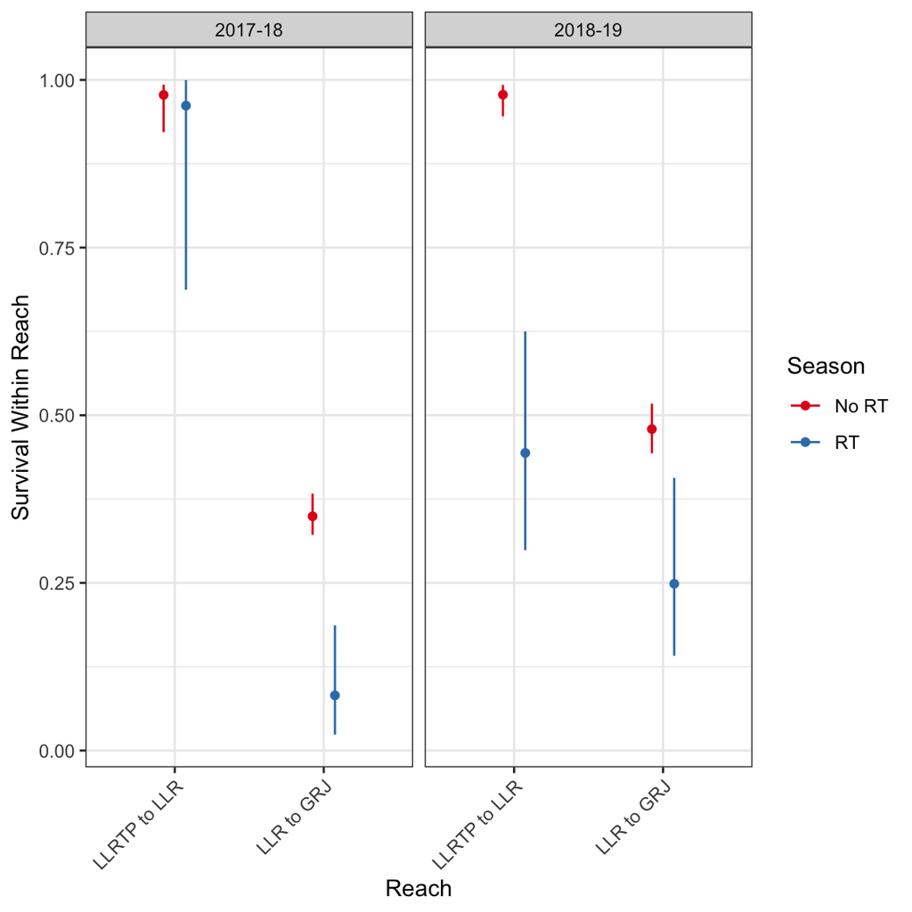

Figure 3.1: Estimates, with 95% confidence intervals, of survival between reaches.

```r
phi_p
```

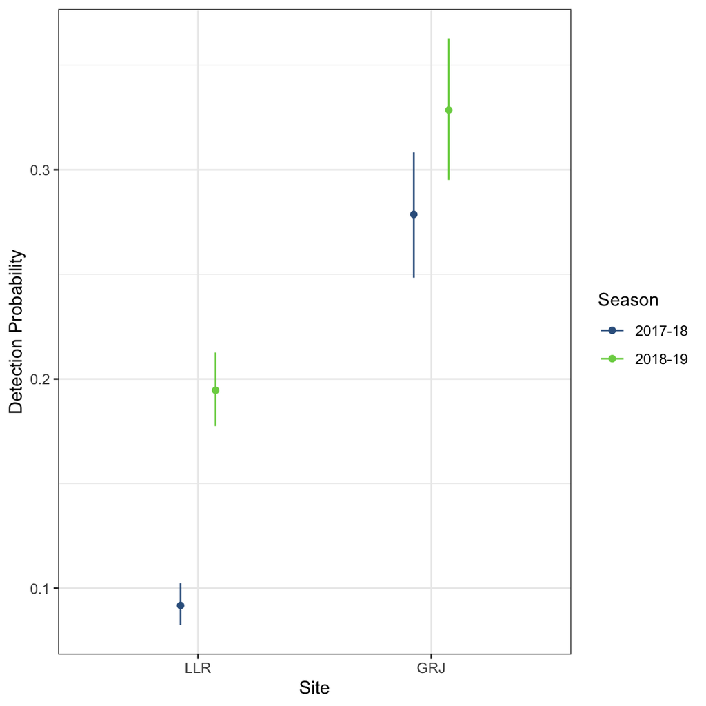

Figure 3.2: Estimates, with 95% confidence intervals, of detection probabilities.

```r
det_p
```

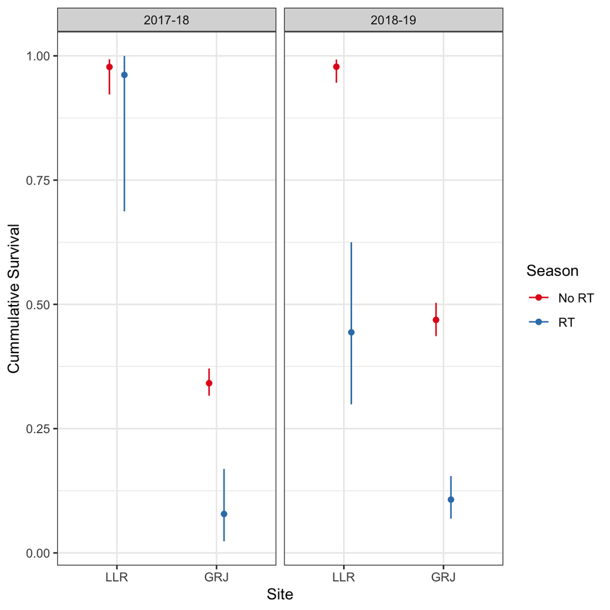

Figure 3.3: Estimates, with 95% confidence intervals, of cummulative survival between reaches.

```r
surv_p
```